# Anniversary Letter

Zain Arifin

27 10 2024

## The Beginning

Hi Babe! It’s me, your husbando. One year ago, we started dating. Time flies no? I admit at that time I was very awkward interacting with you. Not because I don’t love you, but rather because I do not know where the boundaries are. Does not help that both of us are introverted and I am on power saving mode 24/7. In the first 2 months, I would say we have a lot of trial and errors. But hey, we went through that :)

## Now

We are much much better now no? For that, here are my thoughts about you darling (in Shakespearean). Sorry in advance for the nerdiness hehehehehe.

## My love for thee doth rise with fervor unmatched, swelling evermore, as boundless and swift as the stars ascending to eternity (exponential)

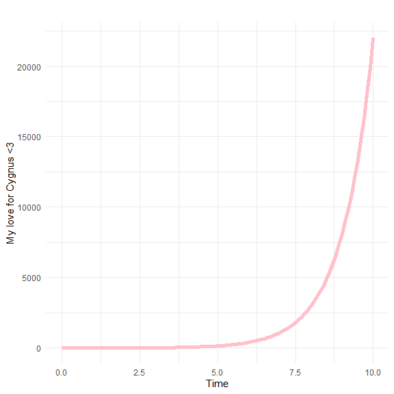

```r
# Define the data frame with x and y values
data <- data.frame(x = seq(0, 10, by = 0.1))
data$y <- exp(data$x)

# Create the plot
ggplot(data, aes(x = x, y = y)) +
  geom_line(color = "pink", size = 2) +
  labs(title = "", x = "Time", y = "My love for Cygnus <3") +
  theme_minimal()
```

## My heart, dear love, is shaped in thine own image—crafted to mirror thy beauty and tender, an endless vessel made to hold thee alone (heart plot)

[figure not shown]

```r
# Math function
t <- seq(0, 2 * pi, length.out = 100)
heart_data <- tibble(
  x = 16 * sin(t)^3,
  y = 13 * cos(t) - 5 * cos(2 * t) - 2 * cos(3 * t) - cos(4 * t),
  frame = rep(1:10, each = 10)
)

# Plot
p <- ggplot(heart_data, aes(x, y)) +
  geom_path(color = "red", size = 1.5) +
  theme_minimal() +
  labs(title = "How I feel aboout you everyday") +
  theme(axis.title = element_blank(), axis.text = element_blank(), axis.ticks = element_blank())

# Animate
animated_heart <- p +
  transition_reveal(along = frame) +
  enter_fade() +
  exit_fade() +
  ease_aes('linear')

# Render
animate(animated_heart, nframes = 50, fps = 50)
```

## In a realm of normal Gaussian distributions of alluring beauties, thou art the singular outlier, radiant and distinct, a rare gem amidst the sea of mediocrity (Gaussian Distribution)

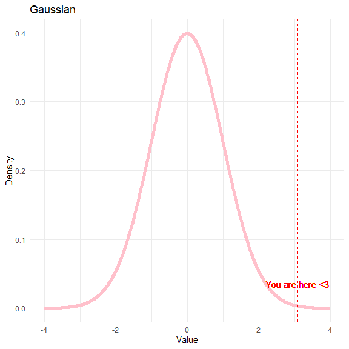

```r
mean <- 0
sd <- 1

# Generate data for the Gaussian distribution
x <- seq(-4, 4, length.out = 1000)
y <- dnorm(x, mean, sd)

data <- data.frame(x, y)
percentile_99 <- qnorm(0.999, mean, sd)

# Create the plot
ggplot(data, aes(x, y)) +
  geom_line(color = "pink", size = 2) +
  geom_vline(xintercept = percentile_99, linetype = "dashed", color = "red") +
  geom_text(aes(x = percentile_99, y = 0.02, label = "You are here <3"),
            color = "red", vjust = -1) +
  labs(title = "Gaussian",
       x = "Value",
       y = "Density") +
  theme_minimal()
```

## Should I propose that my love be but a fleeting fancy, let it be known, my dear, that I reject that null hypothesis with fervor, for my affection for thee is a truth beyond all reasonable doubt! (Hypothesis testing)

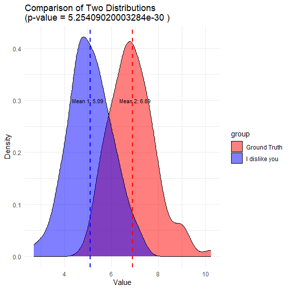

```r
# Set seed
set.seed(123)

# Generate two normal distributions
n <- 100
dist1 <- rnorm(n, mean = 5, sd = 1)
dist2 <- rnorm(n, mean = 7, sd = 1)

data <- data.frame(
  value = c(dist1, dist2),
  group = rep(c("I dislike you", "Ground Truth"), each = n)
)

# Perform a t-test to compare the means
t_test_result <- t.test(dist1, dist2)
p_value <- t_test_result$p.value

# Create the plot
ggplot(data, aes(x = value, fill = group)) +
  geom_density(alpha = 0.5) +
  geom_vline(aes(xintercept = mean(dist1)), color = "blue", linetype = "dashed", size = 1) +
  geom_vline(aes(xintercept = mean(dist2)), color = "red", linetype = "dashed", size = 1) +
  labs(title = paste("Comparison of Two Distributions\n(p-value =", p_value, ")"),
       x = "Value",
       y = "Density") +
  theme_minimal() +
  scale_fill_manual(values = c("I dislike you" = "blue", "Ground Truth" = "red")) +
  annotate("text", x = 5, y = 0.3, label = paste("Mean 1:", round(mean(dist1), 2)), color = "black", size = 3) +
  annotate("text", x = 7, y = 0.3, label = paste("Mean 2:", round(mean(dist2), 2)), color = "black", size = 3)
```

## Dear heart, like the art of PCA, thou dost distill the complexities of my affection, revealing the principal components of my love, where each cherished moment unveils a beauty profound, illuminating the path of our entwined souls.

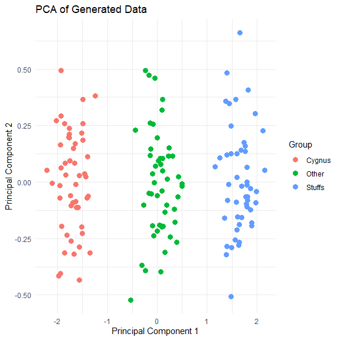

```r
set.seed(123)
n <- 50

cygnus_data <- data.frame(
  Group = rep("Cygnus", n),
  PC1 = rnorm(n, mean = 5, sd = 1),
  PC2 = rnorm(n, mean = 5, sd = 1)
)
other_data <- data.frame(
  Group = rep("Other", n),
  PC1 = rnorm(n, mean = 0, sd = 1),
  PC2 = rnorm(n, mean = 0, sd = 1)
)
stuffs_data <- data.frame(
  Group = rep("Stuffs", n),
  PC1 = rnorm(n, mean = -5, sd = 1),
  PC2 = rnorm(n, mean = -5, sd = 1)
)
all_data <- rbind(cygnus_data, other_data, stuffs_data)

# Scale the data (excluding the Group column)
scaled_data <- scale(all_data[, 2:3])

# Perform PCA
pca_result <- prcomp(scaled_data, center = TRUE, scale. = TRUE)
pca_df <- data.frame(pca_result$x)
pca_df$Group <- all_data$Group

# Plot the PCA results
ggplot(pca_df, aes(x = PC1, y = PC2, color = Group)) +
  geom_point(size = 3) +
  labs(title = "PCA of Generated Data",
       x = "Principal Component 1",
       y = "Principal Component 2") +
  theme_minimal()
```

## Hope you enjoyed this present my love!

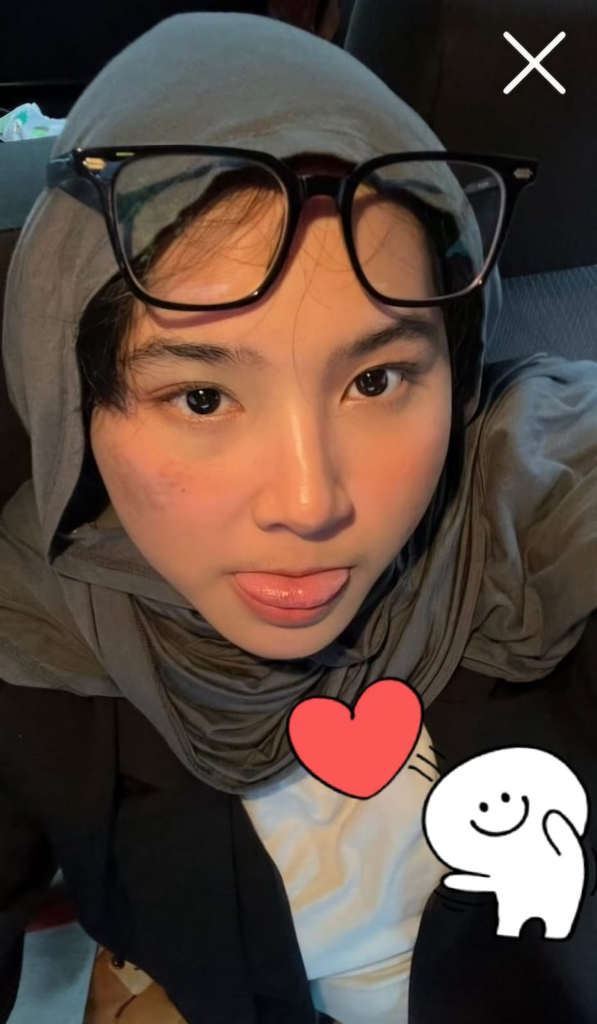